# NATURAL LANGUAGE PROCESSING - SENTIMENT ANALYSIS

## Ricardo López Ruiz

Date: 30/07/2021

## Abstract:

Sentiment analysis is performed on the twitters written by the users of different U.S. airlines.

## Tecniques used in this project:

'Tokenization', 'Removal/Conversion of characters', 'Removal of stopwords', 'Stemming/Lemmatization', 'Counter/Tfidf Vectorization', 'Wordclouds'

# Project - Twitter US Airline Sentiment

## Background and Context:

Twitter possesses 330 million monthly active users, which allows businesses to reach a broad population and connect with customers without intermediaries. On the other hand, there’s so much information that it’s difficult for brands to quickly detect negative social mentions that could harm their business.

That's why sentiment analysis/classification, which involves monitoring emotions in conversations on social media platforms, has become a key strategy in social media marketing.

Listening to how customers feel about the product/service on Twitter allows companies to understand their audience, keep on top of what’s being said about their brand and their competitors, and discover new trends in the industry.

## Data Description:

A sentiment analysis job about the problems of each major U.S. airline. Twitter data was scraped from February of 2015 and contributors were asked to first classify positive, negative, and neutral tweets, followed by categorizing negative reasons (such as "late flight" or "rude service").

## Dataset:

The dataset has the following columns:

```
tweet_id
airline_sentiment
airline_sentiment_confidence
negativereason
negativereason_confidence
airline
airline_sentiment_gold
name
negativereason_gold
retweet_count
text
tweet_coord
tweet_created
tweet_location
user_timezone
```

## Objective and Learning Outcomes:

To implement the techniques for Natural Language Processing:

```
Basic understanding of text pre-processing.
What to do after text pre-processing
Bag of words
Tf-idf
Build the classification model.
Evaluate the Model
```

## Steps:

1. Import the libraries, load dataset, print the shape of data, data description.
2. Exploratory data analysis (EDA) based on the below statements.
   - Plot the distribution of all tweets among each airline & plot the distribution of sentiment across all the tweets.
   - Plot the distribution of Sentiment of tweets for each airline & plot the distribution of all the negative reasons.
   - Plot the word cloud graph of tweets for positive and negative sentiment separately.
3. Understanding of data columns.
   - Drop all other columns except “text” and “airline_sentiment”.
   - Check the shape of the data.
   - Print the first rows of data.
4. Text pre-processing: Data preparation.
   - Html tag removal
   - Removal of http links
   - Replace contractions
   - Remove numbers
   - Tokenization
   - Removal of Special Characters
   - Removal of Punctuations
   - Conversion to lowercase
   - Removal of stopwords
   - Lemmatize or stemming
   - Join the words in the list to convert back to text string in the data frame
   - Print the first rows of data after pre-processing
5. Vectorization.
   - Use CountVectorizer.
   - Use TfidfVectorizer.
6. Fit, tune & evaluate the model using both types of vectorization.
   - Print the top 40 features and plot their word cloud using both types of vectorization.
7. Summary of work performed with pre-processing, vectorization and modelization.

**Import the libraries, load dataset, print the shape of data, data description**

```python
# Install and import necessary libraries.
# contractions and spacy libraries already installed

import re, string, unicodedata                          # Import Regex, string and unicodedata
import contractions                                     # Import contractions library
from bs4 import BeautifulSoup                           # Import BeautifulSoup

import numpy as np                                      # Import numpy
import pandas as pd                                     # Import pandas
import matplotlib.pyplot as plt                         # Import plt for visualization
import seaborn as sns                                   # Used also for plotting
import random                                           # Random tools
from collections import Counter                         # Count the key-value pairs in an object

import warnings                                         # Ignore warnings
warnings.filterwarnings("ignore")

import nltk                                             # Import Natural Language Tool-Kit
nltk.download('stopwords')                              # Download Stopwords
nltk.download('punkt')
nltk.download('wordnet')

from nltk.corpus import stopwords                       # Import stopwords
from nltk.tokenize import word_tokenize, sent_tokenize  # Import Tokenizer
from nltk.stem.wordnet import WordNetLemmatizer         # Import Lemmatizer
from nltk.stem.porter import PorterStemmer              # Used for Stemming of words in the corpus
```

```python
# Loading data
data=pd.read_csv('Tweets.csv')
```

```python
# Shape of data
data.shape                          # print shape of data
```

```
(14640, 15)
```

```python
# Data look
data.head()                         # Print first 5 rows of data with their 15 columns
```

|  | tweet_id | airline_sentiment | airline_sentiment_confidence | negativereason | negativereason_confidence | airline | airline_sentiment_gold | name | negativereason_gold | retweet_count | text | tweet_coord | tweet_created | tweet_location | user_timezone |
| --- | --- | --- | --- | --- | --- | --- | --- | --- | --- | --- | --- | --- | --- | --- | --- |
| 0 | 570306133677760513 | neutral | 1.0000 | NaN | NaN | Virgin America | NaN | cairdin | NaN | 0 | @VirginAmerica What @dhepburn said. | NaN | 2015-02-24 11:35:52 -0800 | NaN | Eastern Time (US & Canada) |
| 1 | 570301130888122368 | positive | 0.3486 | NaN | 0.0000 | Virgin America | NaN | jnardino | NaN | 0 | @VirginAmerica plus you've added commercials t... | NaN | 2015-02-24 11:15:59 -0800 | NaN | Pacific Time (US & Canada) |
| 2 | 570301083672813571 | neutral | 0.6837 | NaN | NaN | Virgin America | NaN | yvonnalynn | NaN | 0 | @VirginAmerica I didn't today... Must mean I n... | NaN | 2015-02-24 11:15:48 -0800 | Lets Play | Central Time (US & Canada) |
| 3 | 570301031407624196 | negative | 1.0000 | Bad Flight | 0.7033 | Virgin America | NaN | jnardino | NaN | 0 | @VirginAmerica it's really aggressive to blast... | NaN | 2015-02-24 11:15:36 -0800 | NaN | Pacific Time (US & Canada) |
| 4 | 570300817074462722 | negative | 1.0000 | Can't Tell | 1.0000 | Virgin America | NaN | jnardino | NaN | 0 | @VirginAmerica and it's a really big bad thing... | NaN | 2015-02-24 11:14:45 -0800 | NaN | Pacific Time (US & Canada) |

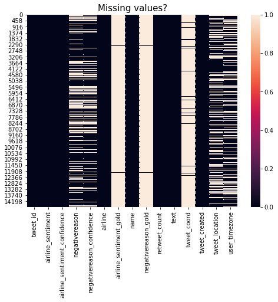

```python
# Visualization of missing values using heatmap
plt.figure(figsize=(8,6))
sns.heatmap(data.isnull())
plt.title("Missing values?", fontsize = 15)
plt.show()
```

- Based on the above plot, we can say as there are many of missing values in several columns.
- The 'airline_sentiment_gold', 'negativereason_gold', 'tweet_coord' columns have near all missing values.
- The 'airline_sentiment' and 'text' columns dont have missing values.

```python
# Check for NULL values in columns
data.isnull().sum(axis=0)
```

```
tweet_id                            0
airline_sentiment                   0
airline_sentiment_confidence        0
negativereason                   5462
negativereason_confidence        4118
airline                             0
airline_sentiment_gold          14600
name                                0
negativereason_gold             14608
retweet_count                       0
text                                0
tweet_coord                     13621
tweet_created                       0
tweet_location                   4733
user_timezone                    4820
dtype: int64
```

```python
# We identify in a new table all the zero and missing values in the columns of our dataframe

def missing_zero_values_table(df):
        zero_val = (df == 0.00).astype(int).sum(axis=0)                                            # Number of zeros in each column
        mis_val = df.isnull().sum()                                                                # Missing values in each column
        mis_val_percent = 100 * df.isnull().sum() / len(df)                                        # Missing value percent accross column
        mz_table = pd.concat([zero_val, mis_val, mis_val_percent], axis=1)                         # Concatenation of above output
        mz_table = mz_table.rename(
        columns = {0 : 'Zero Values', 1 : 'Missing Values', 2 : '% of Total Values'})               # Renaming of each coumn
        mz_table['Total Zero Missing Values'] = mz_table['Zero Values'] + mz_table['Missing Values']  # Column having total of zero value and missing values
        mz_table['% Total Zero Missing Values'] = 100 * mz_table['Total Zero Missing Values'] / len(df) # Column having percentage of total of zero and missing values
        mz_table['Data Type'] = df.dtypes
        mz_table = mz_table[
            mz_table.iloc[:,1] != 0].sort_values(                                                     #Selecting and sorting those column which have at not a zero value in % of Total Values column
        '% of Total Values', ascending=False).round(1)
        print ("Your selected dataframe has " + str(df.shape[1]) + " columns and " + str(df.shape[0]) + " Rows.\n"
            "There are " + str(mz_table.shape[0]) +
              " columns that have missing values.")
#         mz_table.to_excel('D:/sampledata/missing_and_zero_values.xlsx', freeze_panes=(1,0), index = False)
        return mz_table

missing_zero_values_table(data)
```

```
Your selected dataframe has 15 columns and 14640 Rows.
There are 7 columns that have missing values.
```

|  | Zero Values | Missing Values | % of Total Values | Total Zero Missing Values | % Total Zero Missing Values | Data Type |
| --- | --- | --- | --- | --- | --- | --- |
| negativereason_gold | 0 | 14608 | 99.8 | 14608 | 99.8 | object |
| airline_sentiment_gold | 0 | 14600 | 99.7 | 14600 | 99.7 | object |
| tweet_coord | 0 | 13621 | 93.0 | 13621 | 93.0 | object |
| negativereason | 0 | 5462 | 37.3 | 5462 | 37.3 | object |
| user_timezone | 0 | 4820 | 32.9 | 4820 | 32.9 | object |
| tweet_location | 0 | 4733 | 32.3 | 4733 | 32.3 | object |
| negativereason_confidence | 1344 | 4118 | 28.1 | 5462 | 37.3 | float64 |

**Exploratory Data Analysis (EDA)**

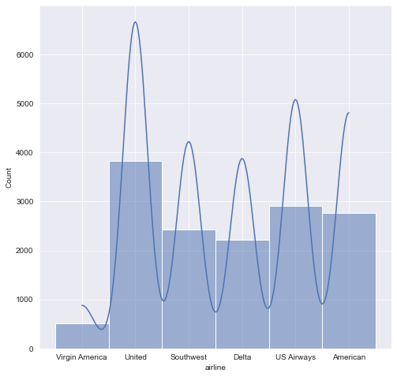

```python
# Distribution of all tweets among each airline
sns.set({'figure.figsize': (8,8)})
sns.histplot(data['airline'], kde=True)
plt.show()
```

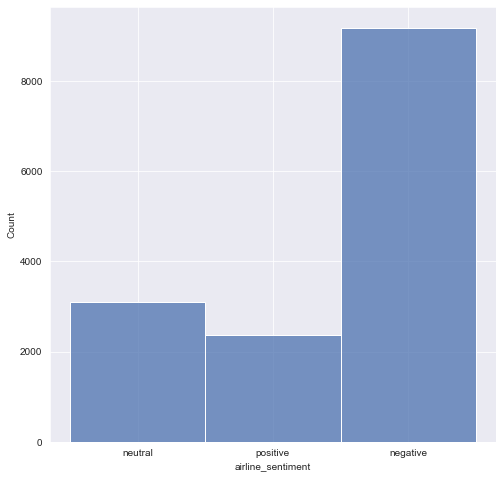

```python
# Distribution of sentiment across all the tweets
sns.set({'figure.figsize': (8,8)})
sns.histplot(data['airline_sentiment'], kde=False)
plt.show()
```

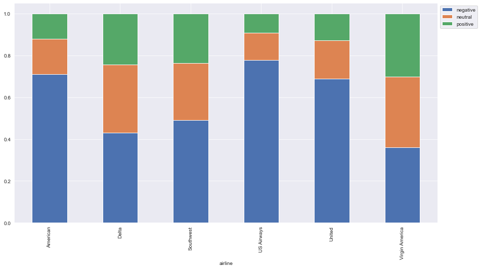

```python
# Distribution of Sentiment of tweets for each airline
tab = pd.crosstab(data["airline"], data["airline_sentiment"], normalize="index")
tab.plot(kind="bar", stacked=True, figsize=(15, 8))
plt.legend(loc="lower left", frameon=False)
plt.legend(loc="upper left", bbox_to_anchor=(1, 1))
plt.show()
```

```
Datos no nulos:  9178
Datos nulos:  5462
Total =  14640
```

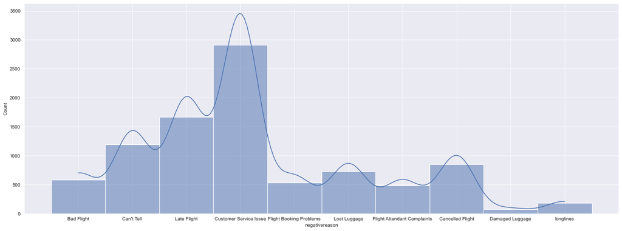

```python
# Distribution of all the negative reasons
df = pd.DataFrame()
df['negativereason'] = data['negativereason']
df1 = df.dropna()
n1 = df1.shape[0]
n2 = data['negativereason'].isnull().sum()
print('Datos no nulos: ', n1)
print('Datos nulos: ', n2)
print('Total = ', n1+n2 )
sns.set({'figure.figsize': (22,8)})
sns.histplot(df1['negativereason'], kde=True)
plt.show()
```

```python
# Word cloud graph of raw tweets for positive and negative sentiment separately

# Function doing the word cloud on the Text column
import wordcloud
def show_wordcloud(data, title):
    text = ' '.join(data['text'].astype(str).tolist())                 # Converting Text column into list
    stopwords = set(wordcloud.STOPWORDS)                               # Instantiate the stopwords from wordcloud

    fig_wordcloud = wordcloud.WordCloud(stopwords=stopwords,background_color='white',  # Setting the different parameter of stopwords
                    colormap='viridis', width=800, height=600).generate(text)

    plt.figure(figsize=(14,11), frameon=True)
    plt.imshow(fig_wordcloud)
    plt.axis('off')
    plt.title(title, fontsize=30)
    plt.show()
```

```python
# We make a copy of data to manipulate/tokenize the column Text
data1 = data.copy()
data1['text'] = data1.apply(lambda row: nltk.word_tokenize(row['text']), axis=1) # Tokenization of data
data1.head()
```

|  | tweet_id | airline_sentiment | airline_sentiment_confidence | negativereason | negativereason_confidence | airline | airline_sentiment_gold | name | negativereason_gold | retweet_count | text | tweet_coord | tweet_created | tweet_location | user_timezone |
| --- | --- | --- | --- | --- | --- | --- | --- | --- | --- | --- | --- | --- | --- | --- | --- |
| 0 | 570306133677760513 | neutral | 1.0000 | NaN | NaN | Virgin America | NaN | cairdin | NaN | 0 | [@, VirginAmerica, What, @, dhepburn, said, .] | NaN | 2015-02-24 11:35:52 -0800 | NaN | Eastern Time (US & Canada) |
| 1 | 570301130888122368 | positive | 0.3486 | NaN | 0.0000 | Virgin America | NaN | jnardino | NaN | 0 | [@, VirginAmerica, plus, you, 've, added, comm... | NaN | 2015-02-24 11:15:59 -0800 | NaN | Pacific Time (US & Canada) |
| 2 | 570301083672813571 | neutral | 0.6837 | NaN | NaN | Virgin America | NaN | yvonnalynn | NaN | 0 | [@, VirginAmerica, I, did, n't, today, ..., Mu... | NaN | 2015-02-24 11:15:48 -0800 | Lets Play | Central Time (US & Canada) |
| 3 | 570301031407624196 | negative | 1.0000 | Bad Flight | 0.7033 | Virgin America | NaN | jnardino | NaN | 0 | [@, VirginAmerica, it, 's, really, aggressive,... | NaN | 2015-02-24 11:15:36 -0800 | NaN | Pacific Time (US & Canada) |
| 4 | 570300817074462722 | negative | 1.0000 | Can't Tell | 1.0000 | Virgin America | NaN | jnardino | NaN | 0 | [@, VirginAmerica, and, it, 's, a, really, big... | NaN | 2015-02-24 11:14:45 -0800 | NaN | Pacific Time (US & Canada) |

```python
# We separate data with positive and negative sentiments
Positive_sent = data1[data1['airline_sentiment']=='positive']
Negative_sent = data1[data1['airline_sentiment']=='negative']
```

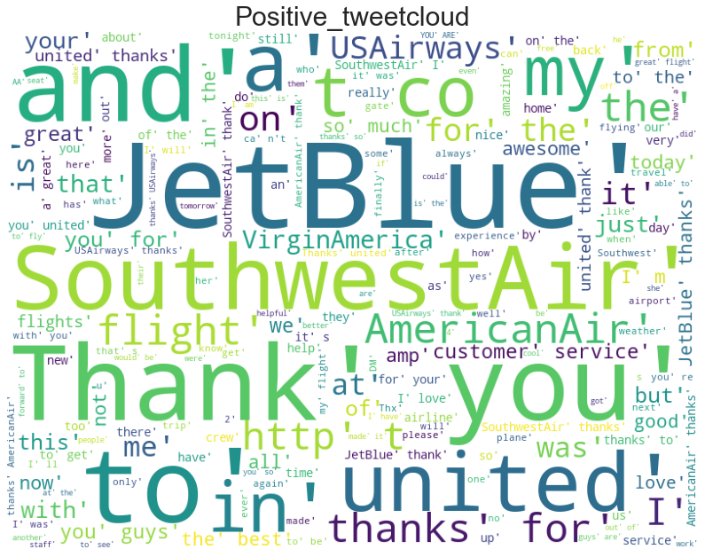

```python
# Plot of the raw tweets with positive sentiment
show_wordcloud(Positive_sent, "Positive_tweetcloud")
```

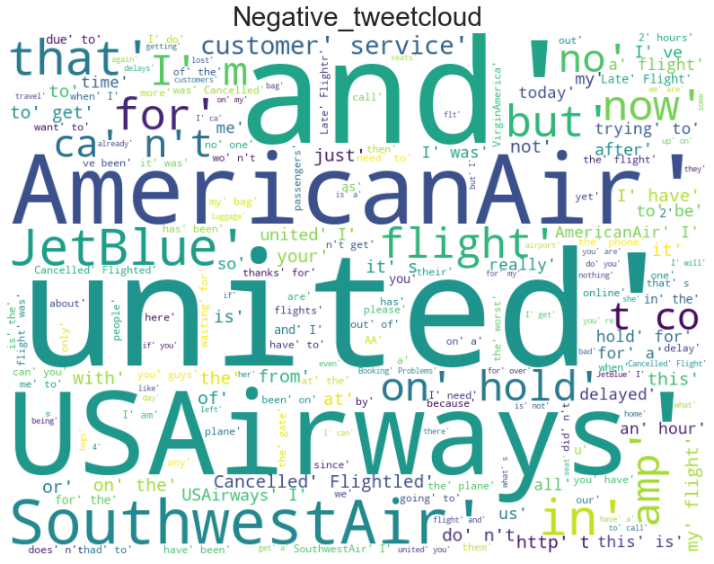

```python
# Plot of the raw tweets with negative sentiment
show_wordcloud(Negative_sent, "Negative_tweetcloud")
```

**Understanding of data columns**

```python
# Taking all the entries for further manipulation and modeling
# Only keeping relevant columns from the data (text and airline_sentiment), as these are useful for our analysis

df = data.loc[:, ['text','airline_sentiment']].copy()
df.rename(columns={'airline_sentiment':'sentiment'}, inplace=True)
```

```python
# Shape of the data
df.shape                      # Shape of the data
```

```
(14640, 2)
```

```python
# Verifying there are no null data
df.isnull().sum(axis=0)       # Check for NULL values
```

```
text         0
sentiment    0
dtype: int64
```

```python
# Checking the head of the new dataframe
pd.set_option('display.max_colwidth', None) # Display full dataframe information (Non-turncated Text column)
df.head(10)
```

|  | text | sentiment |
| --- | --- | --- |
| 0 | @VirginAmerica What @dhepburn said. | neutral |
| 1 | @VirginAmerica plus you've added commercials to the experience... tacky. | positive |
| 2 | @VirginAmerica I didn't today... Must mean I need to take another trip! | neutral |
| 3 | @VirginAmerica it's really aggressive to blast obnoxious "entertainment" in your guests' faces &amp; they have little recourse | negative |
| 4 | @VirginAmerica and it's a really big bad thing about it | negative |
| 5 | @VirginAmerica seriously would pay $30 a flight for seats that didn't have this playing.\nit's really the only bad thing about flying VA | negative |
| 6 | @VirginAmerica yes, nearly every time I fly VX this “ear worm” won’t go away :) | positive |
| 7 | @VirginAmerica Really missed a prime opportunity for Men Without Hats parody, there. https://t.co/mWpG7grEZP | neutral |
| 8 | @virginamerica Well, I didn't…but NOW I DO! :-D | positive |
| 9 | @VirginAmerica it was amazing, and arrived an hour early. You're too good to me. | positive |

**Text pre-processing: Data preparation**

```
- Html tag removal
- Removal of http links
- Replace contractions
- Remove numbers
- Tokenization
- Removal of Special Characters
- Removal of Punctuations
- Conversion to lowercase
- Removal of stopwords
- Lemmatize or stemming
- Normalization of the text
```

```python
# Html tag removal

def strip_html(text):
    soup = BeautifulSoup(text, "html.parser")
    return soup.get_text()

df['text'] = df['text'].apply(lambda x: strip_html(x))

pd.set_option('display.max_colwidth', None)
df.head(10)
```

|  | text | sentiment |
| --- | --- | --- |
| 0 | @VirginAmerica What @dhepburn said. | neutral |
| 1 | @VirginAmerica plus you've added commercials to the experience... tacky. | positive |
| 2 | @VirginAmerica I didn't today... Must mean I need to take another trip! | neutral |
| 3 | @VirginAmerica it's really aggressive to blast obnoxious "entertainment" in your guests' faces & they have little recourse | negative |
| 4 | @VirginAmerica and it's a really big bad thing about it | negative |
| 5 | @VirginAmerica seriously would pay $30 a flight for seats that didn't have this playing.\nit's really the only bad thing about flying VA | negative |
| 6 | @VirginAmerica yes, nearly every time I fly VX this “ear worm” won’t go away :) | positive |
| 7 | @VirginAmerica Really missed a prime opportunity for Men Without Hats parody, there. https://t.co/mWpG7grEZP | neutral |
| 8 | @virginamerica Well, I didn't…but NOW I DO! :-D | positive |
| 9 | @VirginAmerica it was amazing, and arrived an hour early. You're too good to me. | positive |

```python
# Removal of the http link using Regular Expression

for i, row in df.iterrows():
    clean_tweet = re.sub(r"http\S+", "", df.at[i, 'text'])
    df.at[i,'text'] = clean_tweet

pd.set_option('display.max_colwidth', None)
df.head(10)
```

|  | text | sentiment |
| --- | --- | --- |
| 0 | @VirginAmerica What @dhepburn said. | neutral |
| 1 | @VirginAmerica plus you've added commercials to the experience... tacky. | positive |
| 2 | @VirginAmerica I didn't today... Must mean I need to take another trip! | neutral |
| 3 | @VirginAmerica it's really aggressive to blast obnoxious "entertainment" in your guests' faces & they have little recourse | negative |
| 4 | @VirginAmerica and it's a really big bad thing about it | negative |
| 5 | @VirginAmerica seriously would pay $30 a flight for seats that didn't have this playing.\nit's really the only bad thing about flying VA | negative |
| 6 | @VirginAmerica yes, nearly every time I fly VX this “ear worm” won’t go away :) | positive |
| 7 | @VirginAmerica Really missed a prime opportunity for Men Without Hats parody, there. | neutral |
| 8 | @virginamerica Well, I didn't…but NOW I DO! :-D | positive |
| 9 | @VirginAmerica it was amazing, and arrived an hour early. You're too good to me. | positive |

```python
# Replace contractions

def replace_contractions(text):
    """Replace contractions in string of text"""
    return contractions.fix(text)

df['text'] = df['text'].apply(lambda x: replace_contractions(x))

pd.set_option('display.max_colwidth', None)
df.head(20)
```

|  | text | sentiment |
| --- | --- | --- |
| 0 | @VirginAmerica What @dhepburn said. | neutral |
| 1 | @VirginAmerica plus you have added commercials to the experience... tacky. | positive |
| 2 | @VirginAmerica I did not today... Must mean I need to take another trip! | neutral |
| 3 | @VirginAmerica it is really aggressive to blast obnoxious "entertainment" in your guests' faces & they have little recourse | negative |
| 4 | @VirginAmerica and it is a really big bad thing about it | negative |
| 5 | @VirginAmerica seriously would pay $30 a flight for seats that did not have this playing.\nit is really the only bad thing about flying VA | negative |
| 6 | @VirginAmerica yes, nearly every time I fly VX this “ear worm” will not go away :) | positive |
| 7 | @VirginAmerica Really missed a prime opportunity for Men Without Hats parody, there. | neutral |
| 8 | @virginamerica Well, I did not…but NOW I DO! :-D | positive |
| 9 | @VirginAmerica it was amazing, and arrived an hour early. you are too good to me. | positive |
| 10 | @VirginAmerica did you know that suicide is the second leading because of death among teens 10-24 | neutral |
| 11 | @VirginAmerica I <3 pretty graphics. so much better than minimal iconography. :D | positive |
| 12 | @VirginAmerica This is such a great deal! Already thinking about my 2nd trip to @Australia & I have not even gone on my 1st trip yet! ;p | positive |
| 13 | @VirginAmerica @virginmedia I am flying your #fabulous #Seductive skies again! you take all the #stress away from travel | positive |
| 14 | @VirginAmerica Thanks! | positive |
| 15 | @VirginAmerica SFO-PDX schedule is still MIA. | negative |
| 16 | @VirginAmerica So excited for my first cross country flight LAX to MCO I have heard nothing but great things about Virgin America. #29DaysToGo | positive |
| 17 | @VirginAmerica I flew from NYC to SFO last week and could not fully sit in my seat due to two large gentleman on either side of me. HELP! | negative |
| 18 | I ❤️ flying @VirginAmerica. ☺️👍 | positive |
| 19 | @VirginAmerica you know what would be amazingly awesome? BOS-FLL PLEASE!!!!!!! I want to fly with only you. | positive |

```python
# Remove numbers

def remove_numbers(text):
    text = re.sub(r'\d+', '', text)
    return text

df['text'] = df['text'].apply(lambda x: remove_numbers(x))

pd.set_option('display.max_colwidth', None)
df.head(20)
```

|  | text | sentiment |
| --- | --- | --- |
| 0 | @VirginAmerica What @dhepburn said. | neutral |
| 1 | @VirginAmerica plus you have added commercials to the experience... tacky. | positive |
| 2 | @VirginAmerica I did not today... Must mean I need to take another trip! | neutral |
| 3 | @VirginAmerica it is really aggressive to blast obnoxious "entertainment" in your guests' faces & they have little recourse | negative |
| 4 | @VirginAmerica and it is a really big bad thing about it | negative |
| 5 | @VirginAmerica seriously would pay $ a flight for seats that did not have this playing.\nit is really the only bad thing about flying VA | negative |
| 6 | @VirginAmerica yes, nearly every time I fly VX this “ear worm” will not go away :) | positive |
| 7 | @VirginAmerica Really missed a prime opportunity for Men Without Hats parody, there. | neutral |
| 8 | @virginamerica Well, I did not…but NOW I DO! :-D | positive |
| 9 | @VirginAmerica it was amazing, and arrived an hour early. you are too good to me. | positive |
| 10 | @VirginAmerica did you know that suicide is the second leading because of death among teens - | neutral |
| 11 | @VirginAmerica I < pretty graphics. so much better than minimal iconography. :D | positive |
| 12 | @VirginAmerica This is such a great deal! Already thinking about my nd trip to @Australia & I have not even gone on my st trip yet! ;p | positive |
| 13 | @VirginAmerica @virginmedia I am flying your #fabulous #Seductive skies again! you take all the #stress away from travel | positive |
| 14 | @VirginAmerica Thanks! | positive |
| 15 | @VirginAmerica SFO-PDX schedule is still MIA. | negative |
| 16 | @VirginAmerica So excited for my first cross country flight LAX to MCO I have heard nothing but great things about Virgin America. #DaysToGo | positive |
| 17 | @VirginAmerica I flew from NYC to SFO last week and could not fully sit in my seat due to two large gentleman on either side of me. HELP! | negative |
| 18 | I ❤️ flying @VirginAmerica. ☺️👍 | positive |
| 19 | @VirginAmerica you know what would be amazingly awesome? BOS-FLL PLEASE!!!!!!! I want to fly with only you. | positive |

```python
# Tokenization of the text

df['text'] = df.apply(lambda row: nltk.word_tokenize(row['text']), axis=1) # Tokenization of data

pd.set_option('display.max_colwidth', None)
df.head(20)
```

|  | text | sentiment |
| --- | --- | --- |
| 0 | [@, VirginAmerica, What, @, dhepburn, said, .] | neutral |
| 1 | [@, VirginAmerica, plus, you, have, added, commercials, to, the, experience, ..., tacky, .] | positive |
| 2 | [@, VirginAmerica, I, did, not, today, ..., Must, mean, I, need, to, take, another, trip, !] | neutral |
| 3 | [@, VirginAmerica, it, is, really, aggressive, to, blast, obnoxious, ``, entertainment, '', in, your, guests, ', faces, &, they, have, little, recourse] | negative |
| 4 | [@, VirginAmerica, and, it, is, a, really, big, bad, thing, about, it] | negative |
| 5 | [@, VirginAmerica, seriously, would, pay, $, a, flight, for, seats, that, did, not, have, this, playing, ., it, is, really, the, only, bad, thing, about, flying, VA] | negative |
| 6 | [@, VirginAmerica, yes, ,, nearly, every, time, I, fly, VX, this, “, ear, worm, ”, will, not, go, away, :, )] | positive |
| 7 | [@, VirginAmerica, Really, missed, a, prime, opportunity, for, Men, Without, Hats, parody, ,, there, .] | neutral |
| 8 | [@, virginamerica, Well, ,, I, did, not…but, NOW, I, DO, !, :, -D] | positive |
| 9 | [@, VirginAmerica, it, was, amazing, ,, and, arrived, an, hour, early, ., you, are, too, good, to, me, .] | positive |
| 10 | [@, VirginAmerica, did, you, know, that, suicide, is, the, second, leading, because, of, death, among, teens, -] | neutral |
| 11 | [@, VirginAmerica, I, <, pretty, graphics, ., so, much, better, than, minimal, iconography, ., :, D] | positive |
| 12 | [@, VirginAmerica, This, is, such, a, great, deal, !, Already, thinking, about, my, nd, trip, to, @, Australia, &, I, have, not, even, gone, on, my, st, trip, yet, !, ;, p] | positive |
| 13 | [@, VirginAmerica, @, virginmedia, I, am, flying, your, #, fabulous, #, Seductive, skies, again, !, you, take, all, the, #, stress, away, from, travel] | positive |
| 14 | [@, VirginAmerica, Thanks, !] | positive |
| 15 | [@, VirginAmerica, SFO-PDX, schedule, is, still, MIA, .] | negative |
| 16 | [@, VirginAmerica, So, excited, for, my, first, cross, country, flight, LAX, to, MCO, I, have, heard, nothing, but, great, things, about, Virgin, America, ., #, DaysToGo] | positive |
| 17 | [@, VirginAmerica, I, flew, from, NYC, to, SFO, last, week, and, could, not, fully, sit, in, my, seat, due, to, two, large, gentleman, on, either, side, of, me, ., HELP, !] | negative |
| 18 | [I, ❤️, flying, @, VirginAmerica, ., ☺️👍] | positive |
| 19 | [@, VirginAmerica, you, know, what, would, be, amazingly, awesome, ?, BOS-FLL, PLEASE, !, !, !, !, !, !, !, I, want, to, fly, with, only, you, .] | positive |

```python
# Stopwords set for the english language

stopwords1 = stopwords.words('english')

customlist = ['not', "couldn't", 'didn', "didn't", 'doesn', "doesn't", 'hadn', "hadn't", 'hasn',
        "hasn't", 'haven', "haven't", 'isn', "isn't", 'ma', 'mightn', "mightn't", 'mustn',
        "mustn't", 'needn', "needn't", 'shan', "shan't", 'shouldn', "shouldn't", 'wasn',
        "wasn't", 'weren', "weren't", 'won', "won't", 'wouldn', "wouldn't"]

# Set custom stop-word's list as not, couldn't etc. words matter in Sentiment, so we don't remove them from original data

stopwords1 = list(set(stopwords1) - set(customlist))
```

```python
# Different manipulations and cleaning of the words of the text

lemmatizer = WordNetLemmatizer()

def remove_non_ascii(words):
    """Remove non-ASCII characters from list of tokenized words"""
    new_words = []
    for word in words:
        new_word = unicodedata.normalize('NFKD', word).encode('ascii', 'ignore').decode('utf-8', 'ignore')
        new_words.append(new_word)
    return new_words


def remove_punctuation(words):
    """Remove punctuation from list of tokenized words"""
    new_words = []
    for word in words:
        new_word = re.sub(r'[^\w\s]', '', word)
        if new_word != '':
            new_words.append(new_word)
    return new_words


def to_lowercase(words):
    """Convert all characters to lowercase from list of tokenized words"""
    new_words = []
    for word in words:
        new_word = word.lower()
        new_words.append(new_word)
    return new_words


def remove_stopwords(words):
    """Remove stop words from list of tokenized words"""
    new_words = []
    for word in words:
        if word not in stopwords1:
            new_words.append(word)
    return new_words


def lemmatize_list(words):
    new_words = []
    for word in words:
        new_words.append(lemmatizer.lemmatize(word, pos='v'))
    return new_words


def normalize(words):
    words = remove_non_ascii(words)
    words = remove_punctuation(words)
    words = to_lowercase(words)
    words = remove_stopwords(words)
    words = lemmatize_list(words)
    return ' '.join(words)

df['text'] = df.apply(lambda row: normalize(row['text']), axis=1)

pd.set_option('display.max_colwidth', None)
df.head(20)
```

|  | text | sentiment |
| --- | --- | --- |
| 0 | virginamerica dhepburn say | neutral |
| 1 | virginamerica plus add commercials experience tacky | positive |
| 2 | virginamerica not today must mean need take another trip | neutral |
| 3 | virginamerica really aggressive blast obnoxious entertainment guests face little recourse | negative |
| 4 | virginamerica really big bad thing | negative |
| 5 | virginamerica seriously would pay flight seat not play really bad thing fly va | negative |
| 6 | virginamerica yes nearly every time fly vx ear worm not go away | positive |
| 7 | virginamerica really miss prime opportunity men without hat parody | neutral |
| 8 | virginamerica well notbut | positive |
| 9 | virginamerica amaze arrive hour early good | positive |
| 10 | virginamerica know suicide second lead death among teens | neutral |
| 11 | virginamerica pretty graphics much better minimal iconography | positive |
| 12 | virginamerica great deal already think nd trip australia not even go st trip yet p | positive |
| 13 | virginamerica virginmedia fly fabulous seductive sky take stress away travel | positive |
| 14 | virginamerica thank | positive |
| 15 | virginamerica sfopdx schedule still mia | negative |
| 16 | virginamerica excite first cross country flight lax mco hear nothing great things virgin america daystogo | positive |
| 17 | virginamerica fly nyc sfo last week could not fully sit seat due two large gentleman either side help | negative |
| 18 | fly virginamerica | positive |
| 19 | virginamerica know would amazingly awesome bosfll please want fly | positive |

```python
# We separate data with positive and negative sentiments
Positive_sent1 = df[df['sentiment']=='positive']
Negative_sent1 = df[df['sentiment']=='negative']
```

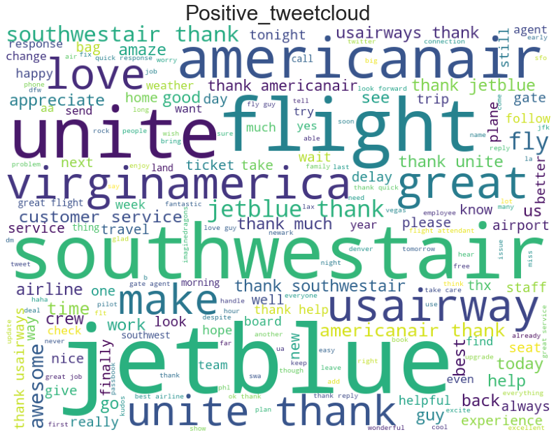

```python
# Plot of the processed text tweets with positive sentiment
show_wordcloud(Positive_sent1, "Positive_tweetcloud")
```

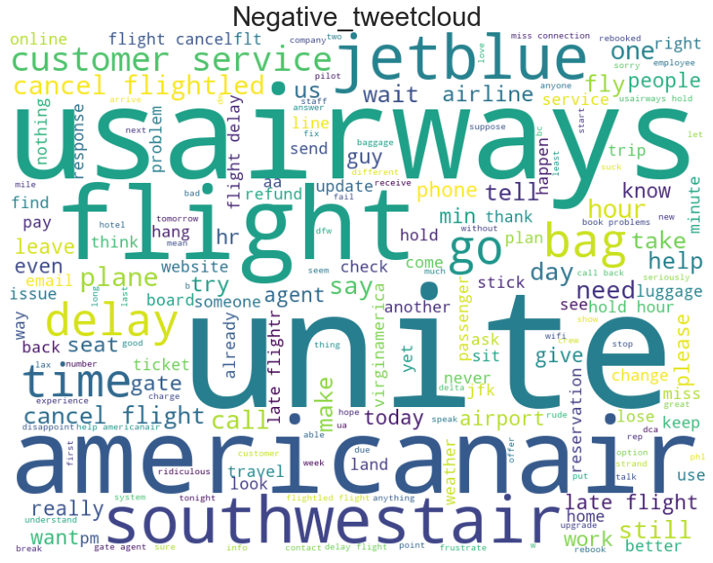

```python
# Plot of the processed text tweets with negative sentiment
show_wordcloud(Negative_sent1, "Negative_tweetcloud")
```

```python
# Tokenization of data for counting the number of words
df['text'] = df.apply(lambda row: nltk.word_tokenize(row['text']), axis=1)
```

```python
# The most Common_words in the Text column

top = Counter([item for sublist in df['text'] for item in sublist])
freq = pd.DataFrame(top.most_common(30))
freq.columns = ['Common_words','count']
freq.style.background_gradient(cmap='Reds')
```

|  | Common_words | count |
| --- | --- | --- |
| 0 | flight | 4836 |
| 1 | unite | 4161 |
| 2 | not | 3903 |
| 3 | usairways | 3051 |
| 4 | americanair | 2962 |
| 5 | southwestair | 2461 |
| 6 | jetblue | 2395 |
| 7 | get | 2120 |
| 8 | thank | 1686 |
| 9 | cancel | 1056 |
| 10 | service | 996 |
| 11 | delay | 991 |
| 12 | time | 954 |
| 13 | help | 951 |
| 14 | go | 798 |
| 15 | call | 778 |
| 16 | fly | 776 |
| 17 | bag | 768 |
| 18 | wait | 752 |
| 19 | customer | 751 |
| 20 | us | 745 |
| 21 | would | 739 |
| 22 | hold | 715 |
| 23 | make | 693 |
| 24 | need | 686 |
| 25 | hours | 681 |
| 26 | plane | 631 |
| 27 | try | 586 |
| 28 | still | 582 |
| 29 | please | 570 |

```python
# Splitting the positive and negative sentiment tweets
Positive_sent2 = df[df['sentiment']=='positive']
Negative_sent2 = df[df['sentiment']=='negative']
print('Number of tweets with positive sentiment', Positive_sent2['sentiment'].count())
print('Number of tweets with negative sentiment', Negative_sent2['sentiment'].count())
```

```
Number of tweets with positive sentiment 2363
Number of tweets with negative sentiment 9178
```

```python
# Most Common-words in the positive sentiments
top = Counter([item for sublist in Positive_sent2['text'] for item in sublist])
freq_positive = pd.DataFrame(top.most_common(20))
freq_positive.columns = ['Common_words','count']
freq_positive.style.background_gradient(cmap='Greens')
```

|  | Common_words | count |
| --- | --- | --- |
| 0 | thank | 1065 |
| 1 | jetblue | 595 |
| 2 | southwestair | 576 |
| 3 | unite | 528 |
| 4 | flight | 443 |
| 5 | americanair | 355 |
| 6 | usairways | 276 |
| 7 | get | 255 |
| 8 | great | 236 |
| 9 | not | 199 |
| 10 | love | 171 |
| 11 | service | 163 |
| 12 | virginamerica | 156 |
| 13 | make | 154 |
| 14 | fly | 153 |
| 15 | guy | 123 |
| 16 | help | 116 |
| 17 | customer | 114 |
| 18 | much | 109 |
| 19 | time | 108 |

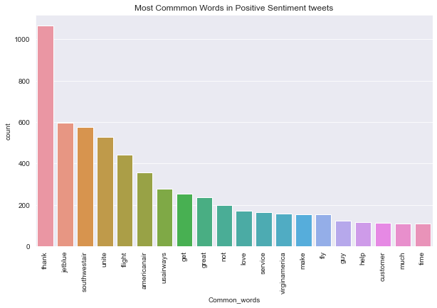

```python
# Plot for the Common_words with positive sentiments
fig, ax = plt.subplots(figsize=(10, 6))
sns.barplot(x='Common_words', y='count',
            data=freq_positive, ax=ax)
plt.title("Most Commmon Words in Positive Sentiment tweets")
plt.xticks(rotation='vertical');
```

```python
# Most Common_words in the negative sentiments
top = Counter([item for sublist in Negative_sent2['text'] for item in sublist])
freq_negative = pd.DataFrame(top.most_common(20))
freq_negative.columns = ['Common_words','count']
freq_negative.style.background_gradient(cmap='flare')
```

|  | Common_words | count |
| --- | --- | --- |
| 0 | flight | 3595 |
| 1 | not | 3323 |
| 2 | unite | 2896 |
| 3 | usairways | 2374 |
| 4 | americanair | 2108 |
| 5 | get | 1521 |
| 6 | southwestair | 1214 |
| 7 | jetblue | 1052 |
| 8 | cancel | 920 |
| 9 | delay | 902 |
| 10 | service | 770 |
| 11 | time | 741 |
| 12 | call | 690 |
| 13 | hold | 677 |
| 14 | wait | 668 |
| 15 | help | 665 |
| 16 | bag | 662 |
| 17 | hours | 656 |
| 18 | customer | 608 |
| 19 | go | 571 |

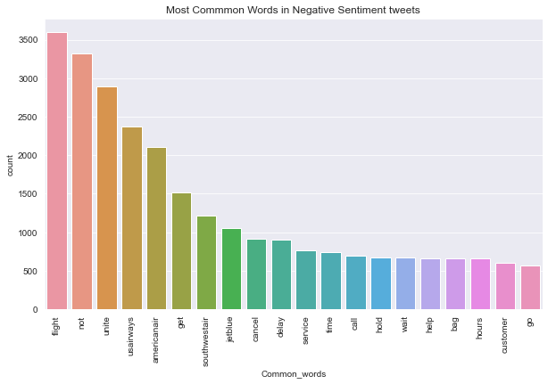

```python
# Plot for the Common_words with negative sentiments
fig, ax = plt.subplots(figsize=(10, 6))
sns.barplot(x='Common_words', y='count',
            data=freq_negative, ax=ax)
plt.title("Most Commmon Words in Negative Sentiment tweets")
plt.xticks(rotation='vertical');
```

```python
# Undoing the tokenization of the Text column

def normalize(words):
    return ' '.join(words)

df['text'] = df.apply(lambda row: normalize(row['text']), axis=1)

pd.set_option('display.max_colwidth', None)
df.head(10)
```

|  | text | sentiment |
| --- | --- | --- |
| 0 | virginamerica dhepburn say | neutral |
| 1 | virginamerica plus add commercials experience tacky | positive |
| 2 | virginamerica not today must mean need take another trip | neutral |
| 3 | virginamerica really aggressive blast obnoxious entertainment guests face little recourse | negative |
| 4 | virginamerica really big bad thing | negative |
| 5 | virginamerica seriously would pay flight seat not play really bad thing fly va | negative |
| 6 | virginamerica yes nearly every time fly vx ear worm not go away | positive |
| 7 | virginamerica really miss prime opportunity men without hat parody | neutral |
| 8 | virginamerica well notbut | positive |
| 9 | virginamerica amaze arrive hour early good | positive |

**Vectorization with CountVectorizer & fit and tuning of the Random Forest model**

```python
# Vectorization (Convert text data to numbers)
from sklearn.feature_extraction.text import CountVectorizer

bow_vec = CountVectorizer(max_features=150)        # Keep only 150 features as number of features will increase the processing time
df_features = bow_vec.fit_transform(df['text'])

df_features = df_features.toarray()                # Convert the data features to array
```

```python
# Shape of the features array and 1 component of this array
print(df_features.shape)
df_features[25]
```

```
(14640, 150)
```

```
array([0, 0, 0, 0, 0, 0, 0, 0, 0, 0, 0, 0, 0, 0, 0, 0, 0, 0, 1, 0, 0, 0,
       0, 0, 0, 0, 0, 0, 0, 0, 0, 0, 0, 1, 0, 0, 0, 0, 0, 0, 0, 0, 0, 0,
       0, 0, 0, 0, 0, 0, 0, 0, 0, 0, 0, 0, 0, 0, 0, 0, 0, 0, 0, 0, 0, 0,
       0, 0, 0, 0, 0, 0, 0, 0, 0, 0, 0, 0, 0, 0, 0, 0, 0, 0, 0, 0, 0, 0,
       0, 0, 0, 0, 0, 0, 0, 0, 0, 0, 0, 0, 0, 0, 0, 1, 0, 0, 0, 0, 0, 0,
       0, 0, 0, 0, 0, 0, 0, 0, 0, 0, 0, 0, 0, 0, 0, 0, 0, 0, 0, 0, 0, 0,
       0, 0, 0, 0, 0, 0, 0, 1, 0, 0, 0, 0, 0, 0, 0, 0, 0, 0], dtype=int64)
```

```python
# Typing the labels as categorical
labels = df['sentiment']
labels = labels.astype('category')
print(labels.shape)
labels
```

```
(14640,)
```

```
0         neutral
1        positive
2         neutral
3        negative
4        negative
           ...
14635    positive
14636    negative
14637     neutral
14638    negative
14639     neutral
Name: sentiment, Length: 14640, dtype: category
Categories (3, object): ['negative', 'neutral', 'positive']
```

```python
# Split data into training and testing set

from sklearn.model_selection import train_test_split

X_train, X_test, y_train, y_test = train_test_split(df_features, labels, test_size=0.3, random_state=15)
```

```python
# Using Random Forest to build model for the classification of reviews
# Also calculating the cross validation score
# Different parameters are tried to increase the score

from sklearn.ensemble import RandomForestClassifier
from sklearn.model_selection import cross_val_score

forest = RandomForestClassifier(n_estimators=30, n_jobs=6)
forest = forest.fit(X_train, y_train)

print(forest)
print(np.mean(cross_val_score(forest, df_features, labels, cv=25)))
```

```
RandomForestClassifier(n_estimators=30, n_jobs=6)
0.7042548350398181
```

```python
# Other way to optimize the number of trees in RF model (n_estimators)
# Finding optimal number of base learners using k-fold CV (cross validation)
base_ln = [x for x in range(1, 30)]
cv_scores = []
for b in base_ln:
    clf = RandomForestClassifier(n_estimators = b)
    scores = cross_val_score(clf, X_train, y_train, cv = 5, scoring = 'accuracy')
    cv_scores.append(scores.mean())
    print('b = ', b, '->', 'score = ', scores.mean())
```

```
b =  1 -> score =  0.6348560749443511
b =  2 -> score =  0.6874504874477735
b =  3 -> score =  0.6840361865990549
b =  4 -> score =  0.6970142246664047
b =  5 -> score =  0.7024790201049889
b =  6 -> score =  0.7068694068492662
b =  7 -> score =  0.708625218726565
b =  8 -> score =  0.7153598781082978
b =  9 -> score =  0.7097003416300636
b =  10 -> score =  0.7138962730183671
b =  11 -> score =  0.7113582592341297
b =  12 -> score =  0.7167256841528884
b =  13 -> score =  0.7159448154364414
b =  14 -> score =  0.7160426144817817
b =  15 -> score =  0.7150666238141152
b =  16 -> score =  0.7182871835160519
b =  17 -> score =  0.7196526562630194
b =  18 -> score =  0.720824292635313
b =  19 -> score =  0.7200439952862194
b =  20 -> score =  0.7217998547774643
b =  21 -> score =  0.7199457201014178
b =  22 -> score =  0.7204334773655204
b =  23 -> score =  0.7201410325084218
b =  24 -> score =  0.7220931090716471
b =  25 -> score =  0.7224828768346249
b =  26 -> score =  0.722190765275149
b =  27 -> score =  0.7244347153281195
b =  28 -> score =  0.7206295515956624
b =  29 -> score =  0.7259960718494446
```

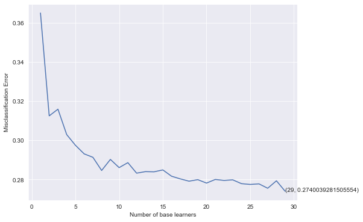

```python
# Plotting the error as k increases
error = [1 - x for x in cv_scores]                    #Error corresponds to each number of estimators
optimal_learners = base_ln[error.index(min(error))]   #Selection of optimal numb of n_estimator corresponds to minimum error
sns.set({'figure.figsize': (8,6)})
plt.plot(base_ln, error)                              #Plot between each numb of estimators and misclassification error
xy = (optimal_learners, min(error))
plt.annotate('(%s, %s)' % xy, xy = xy, textcoords='data')
plt.xlabel("Number of base learners")
plt.ylabel("Misclassification Error")
plt.show()
```

```python
# Training the best model and calculating accuracy on test data
clf = RandomForestClassifier(n_estimators = optimal_learners)
clf.fit(X_train, y_train)
clf.score(X_test, y_test)
```

```
0.7133424408014571
```

```python
# Saving the prediction on test data as a result
result =  clf.predict(X_test)
print('3 examples: ',result[15],result[85],result[185])
result
```

```
3 examples:  negative neutral positive
```

```
array(['negative', 'negative', 'negative', ..., 'negative', 'negative',
       'negative'], dtype=object)
```

```
[[2343  262  111]
 [ 438  386  116]
 [ 199  133  404]]
0.7133424408014571
1 -> negative ; 2 -> neutral ; 3 -> positive
```

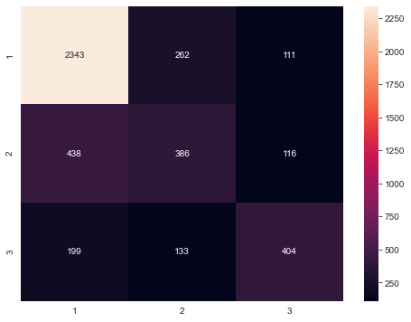

```python
# Print and plot Confusion matrix to get an idea of how the distribution of the prediction is among all the classes.

from sklearn import metrics
from sklearn.metrics import confusion_matrix

conf_mat = confusion_matrix(y_test, result)

print(conf_mat)
print(metrics.f1_score(y_test, result, average='micro'))

df_cm = pd.DataFrame(conf_mat, index = [i for i in "123"],
                  columns = [i for i in "123"])
plt.figure(figsize = (8,6))
sns.heatmap(df_cm, annot=True, fmt='g')
print('1 ->', 'negative', ';', '2 ->', 'neutral', ';', '3 ->', 'positive')
```

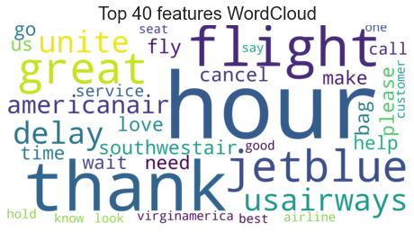

```python
# Word Cloud of top 40 important features from the CountVectorizer + Random Forest based model

all_features = bow_vec.get_feature_names()   # Instantiate the feature from the vectorizer
top_features=''                              # Addition of top 40 feature into top_feature after training the model
feat=clf.feature_importances_
features=np.argsort(feat)[::-1]
for i in features[0:40]:
    top_features+=all_features[i]
    top_features+=' '

# Generation of the wordcloud
from wordcloud import WordCloud
wordcloud1 = WordCloud(background_color="white",colormap='viridis',width=2000,
                          height=1000).generate(top_features)

# Display the generated image
plt.imshow(wordcloud1, interpolation='bilinear')
plt.figure(1, figsize=(14, 11), frameon='equal')
plt.title('Top 40 features WordCloud', fontsize=20)
plt.axis("off")
plt.show()
```

**Vectorization with TfidfVectorizer & fit and tuning of the Random Forest model**

```python
# Using TfidfVectorizer to convert Text column to numbers

from sklearn.feature_extraction.text import TfidfVectorizer

vectorizer = TfidfVectorizer(max_features=150)
data_features = vectorizer.fit_transform(df['text'])

data_features = data_features.toarray()
```

```python
# Shape of the features array and 1 component of this array
print(data_features.shape)
data_features[25]
```

```
(14640, 150)
```

```
array([0.        , 0.        , 0.        , 0.        , 0.        ,
       0.        , 0.        , 0.        , 0.        , 0.        ,
       0.        , 0.        , 0.        , 0.        , 0.        ,
       0.        , 0.        , 0.        , 0.43157735, 0.        ,
       0.        , 0.        , 0.        , 0.        , 0.        ,
       0.        , 0.        , 0.        , 0.        , 0.        ,
       0.        , 0.        , 0.        , 0.53080934, 0.        ,
       0.        , 0.        , 0.        , 0.        , 0.        ,
       0.        , 0.        , 0.        , 0.        , 0.        ,
       0.        , 0.        , 0.        , 0.        , 0.        ,
       0.        , 0.        , 0.        , 0.        , 0.        ,
       0.        , 0.        , 0.        , 0.        , 0.        ,
       0.        , 0.        , 0.        , 0.        , 0.        ,
       0.        , 0.        , 0.        , 0.        , 0.        ,
       0.        , 0.        , 0.        , 0.        , 0.        ,
       0.        , 0.        , 0.        , 0.        , 0.        ,
       0.        , 0.        , 0.        , 0.        , 0.        ,
       0.        , 0.        , 0.        , 0.        , 0.        ,
       0.        , 0.        , 0.        , 0.        , 0.        ,
       0.        , 0.        , 0.        , 0.        , 0.        ,
       0.        , 0.        , 0.        , 0.56319956, 0.        ,
       0.        , 0.        , 0.        , 0.        , 0.        ,
       0.        , 0.        , 0.        , 0.        , 0.        ,
       0.        , 0.        , 0.        , 0.        , 0.        ,
       0.        , 0.        , 0.        , 0.        , 0.        ,
       0.        , 0.        , 0.        , 0.        , 0.        ,
       0.        , 0.        , 0.        , 0.        , 0.        ,
       0.        , 0.        , 0.        , 0.        , 0.46345301,
       0.        , 0.        , 0.        , 0.        , 0.        ,
       0.        , 0.        , 0.        , 0.        , 0.        ])
```

```python
# Split data into training and testing set

from sklearn.model_selection import train_test_split

X_train, X_test, y_train, y_test = train_test_split(data_features, labels, test_size=0.3, random_state=25)
```

```python
# Using Random Forest to build model for the classification of reviews
# Also calculating the cross validation score

from sklearn.ensemble import RandomForestClassifier
from sklearn.model_selection import cross_val_score
import numpy as np

forest = RandomForestClassifier(n_estimators=10, n_jobs=4)
forest = forest.fit(X_train, y_train)

print(forest)
print(np.mean(cross_val_score(forest, data_features, labels, cv=5)))
```

```
RandomForestClassifier(n_estimators=10, n_jobs=4)
0.657103825136612
```

```python
# K - Fold Cross Validation
cv_scores = []
for b in base_ln:
    clf = RandomForestClassifier(n_estimators = b)
    scores = cross_val_score(clf, X_train, y_train, cv = 5, scoring = 'accuracy')
    cv_scores.append(scores.mean())
    print('b = ', b, '->', 'score = ', scores.mean())
```

```
b =  1 -> score =  0.6501749098310896
b =  2 -> score =  0.6975006487400159
b =  3 -> score =  0.6942810413170017
b =  4 -> score =  0.7123330595531431
b =  5 -> score =  0.7076489899891677
b =  6 -> score =  0.7190669094977917
b =  7 -> score =  0.7217990453403803
b =  8 -> score =  0.7226767132092989
b =  9 -> score =  0.7243361068456952
b =  10 -> score =  0.7279456248735254
b =  11 -> score =  0.7255070766227428
b =  12 -> score =  0.7294111345213012
b =  13 -> score =  0.7300921091787784
b =  14 -> score =  0.7289223773643301
b =  15 -> score =  0.7310690521253675
b =  16 -> score =  0.730386410979776
b =  17 -> score =  0.7312631265697722
b =  18 -> score =  0.7325319906200527
b =  19 -> score =  0.7330203668654549
b =  20 -> score =  0.7332158697282434
b =  21 -> score =  0.7318497303860301
b =  22 -> score =  0.7348741206299325
b =  23 -> score =  0.7337029127831542
b =  24 -> score =  0.7353630682426882
b =  25 -> score =  0.7322397838326845
b =  26 -> score =  0.7333127164946612
b =  27 -> score =  0.7354602483067291
b =  28 -> score =  0.7364350486257425
b =  29 -> score =  0.7386794272042281
```

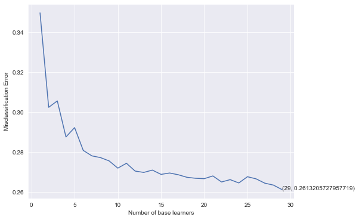

```python
# Plotting the error as k increases
error = [1 - x for x in cv_scores]                        #Error corresponds to each numb of estimators
optimal_learners = base_ln[error.index(min(error))]       #Selection of optimal n_estimator corresponds to minimum error.
sns.set({'figure.figsize': (8,6)})
plt.plot(base_ln, error)                                  #Plot between each n_estimator and misclassification error
xy = (optimal_learners, min(error))
plt.annotate('(%s, %s)' % xy, xy = xy, textcoords='data')
plt.xlabel("Number of base learners")
plt.ylabel("Misclassification Error")
plt.show()
```

```python
# Training the best model and calculating error on test data
clf = RandomForestClassifier(n_estimators = optimal_learners)
clf.fit(X_train, y_train)
clf.score(X_test, y_test)
```

```
0.7222222222222222
```

```python
# Saving the prediction on test data as a result
result =  clf.predict(X_test)
print('3 examples: ',result[16],result[46],result[106])
result
```

```
3 examples:  negative positive neutral
```

```
array(['negative', 'negative', 'negative', ..., 'neutral', 'negative',
       'negative'], dtype=object)
```

```
[[2399  255   75]
 [ 437  406  112]
 [ 216  125  367]]
0.7222222222222222
1 -> negative ; 2 -> neutral ; 3 -> positive
```

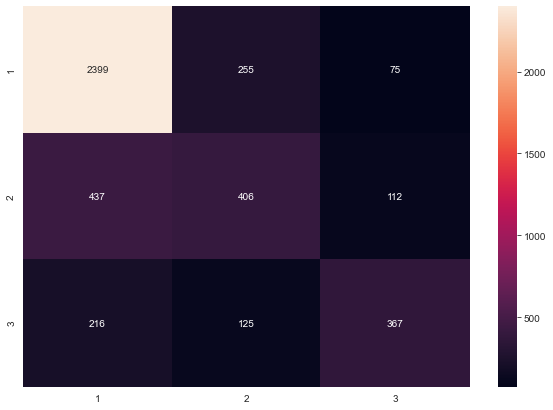

```python
# Print and plot Confusion matrix to get an idea of how the distribution of the prediction is among all the classes

result =  clf.predict(X_test)
conf_mat = confusion_matrix(y_test, result)

print(conf_mat)
print(metrics.f1_score(y_test, result,average='micro'))

df_cm = pd.DataFrame(conf_mat, index = [i for i in "123"],
                  columns = [i for i in "123"])
plt.figure(figsize = (10,7))
sns.heatmap(df_cm, annot=True, fmt='g')
print('1 ->', 'negative', ';', '2 ->', 'neutral', ';', '3 ->', 'positive')
```

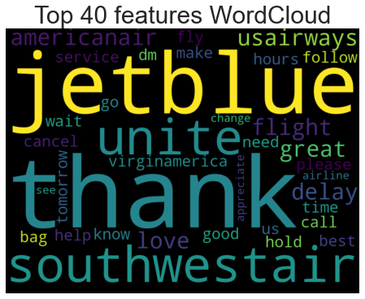

```python
# Word Cloud of top 40 important features from the TfidfVectorizer + Random Forest based model

all_features = vectorizer.get_feature_names()    #Instantiate the feature from the vectorizer
Top_features=''                                  #Addition of top 40 feature into top_feature after training the model
feat=clf.feature_importances_
features=np.argsort(feat)[::-1]
for i in features[0:40]:
    Top_features+=all_features[i]
    Top_features+=' '


from wordcloud import WordCloud
wordcloud = WordCloud(background_color="Black",width=1000,
                          height=750).generate(Top_features)

# Display the generated image
plt.imshow(wordcloud, interpolation='bilinear')
plt.figure(1, figsize=(30, 30), frameon='equal')
plt.title('Top 40 features WordCloud', fontsize=30)
plt.axis("off")
plt.show()
```

**Summary**

- We used a dataset which has **reviews in text format and their sentiment score: negative, neutral, positive**.
- The goal was to **build a model for text-classification**.
- We **created the sentiment and text columns** based on the airline_sentiment and text columns.
- We **pre-processed the data** using various techniques and libraries.
- We **created a Word Cloud plot** based on the raw text of the tweets.
- The **pre-processed data is converted to numbers (vectorized)**, so that we can feed the data into the model.
- We trained the model and optimized the parameter, which **led to an increase the overall accuracy**.
- After building the classification model, we **predicted the results for the test data**.
- We saw that using the above techniques, our model performed well in perspective of how text classification models perform.
- We can also increase the **max_feature parameter** in the vectorizer. We limited it to 150.
- We can apply **other model tuning and hyperparameter tuning techniques, as well as other pre-processing techniques** to increase the overall accuracy even further.